# Network visualization

Kushal K Dey

March 30, 2016

## Overview

We present an overview of the network visualization tools available in R.

```r
install.packages("igraph",repos = "http://cran.us.r-project.org")
install.packages("network", repos = "http://cran.us.r-project.org")
install.packages("sna", repos = "http://cran.us.r-project.org")
install.packages("ndtv", repos = "http://cran.us.r-project.org")
install.packages("RColorBrewer",repos = "http://cran.us.r-project.org")
install.packages("extrafont",repos = "http://cran.us.r-project.org")
```

We load the libraries

```r
library(igraph)
library(network)
library(sna)
library(ndtv)
library(RColorBrewer)
library(extrafont)
```

Load an example network data

```r
nodes <- read.csv("../external_data/Dataset1-Media-Example-NODES.csv", header=T, as.is=T)
links <- read.csv("../external_data/Dataset1-Media-Example-EDGES.csv", header=T, as.is=T)
```

A brief look at the data

```r
head(nodes)
```

```
##    id               media media.type type.label audience.size
## 1 s01            NY Times          1  Newspaper            20
## 2 s02     Washington Post          1  Newspaper            25
## 3 s03 Wall Street Journal          1  Newspaper            30
## 4 s04           USA Today          1  Newspaper            32
## 5 s05            LA Times          1  Newspaper            20
## 6 s06       New York Post          1  Newspaper            50
```

```r
head(links)
```

```
##   from  to weight      type
## 1  s01 s02     10 hyperlink
## 2  s01 s02     12 hyperlink
## 3  s01 s03     22 hyperlink
## 4  s01 s04     21 hyperlink
## 5  s04 s11     22   mention
## 6  s05 s15     21   mention
```

```r
nrow(nodes); length(unique(nodes$id))
```

```
## [1] 17
```

```
## [1] 17
```

```r
nrow(links); nrow(unique(links[,c("from", "to")]))
```

```
## [1] 52
```

```
## [1] 49
```

```r
links <- aggregate(links[,3], links[,-3], sum)
links <- links[order(links$from, links$to),]
colnames(links)[4] <- "weight"
rownames(links) <- NULL
```

Load an example matrix data

```r
nodes2 <- read.csv("../external_data/Dataset2-Media-User-Example-NODES.csv", header=T, as.is=T)
links2 <- read.csv("../external_data/Dataset2-Media-User-Example-EDGES.csv", header=T, row.names=1)

links2 <- as.matrix(links2)
dim(links2)
```

```
## [1] 10 20
```

```r
dim(nodes2)
```

```
## [1] 30  5
```

```r
library(igraph)
net <- graph.data.frame(links, nodes, directed=T)
net
```

```
## IGRAPH DNW- 17 49 --
## + attr: name (v/c), media (v/c), media.type (v/n), type.label
## | (v/c), audience.size (v/n), type (e/c), weight (e/n)
## + edges (vertex names):
##  [1] s01->s02 s01->s03 s01->s04 s01->s15 s02->s01 s02->s03 s02->s09
##  [8] s02->s10 s03->s01 s03->s04 s03->s05 s03->s08 s03->s10 s03->s11
## [15] s03->s12 s04->s03 s04->s06 s04->s11 s04->s12 s04->s17 s05->s01
## [22] s05->s02 s05->s09 s05->s15 s06->s06 s06->s16 s06->s17 s07->s03
## [29] s07->s08 s07->s10 s07->s14 s08->s03 s08->s07 s08->s09 s09->s10
## [36] s10->s03 s12->s06 s12->s13 s12->s14 s13->s12 s13->s17 s14->s11
## [43] s14->s13 s15->s01 s15->s04 s15->s06 s16->s06 s16->s17 s17->s04
```

The description of an igraph object starts with four letters:

D or U, for a directed or undirected graph N for a named graph (where nodes have a name attribute) W for a weighted graph (where edges have a weight attribute) B for a bipartite (two-mode) graph (where nodes have a type attribute)

(g/c) - graph-level character attribute (v/c) - vertex-level character attribute (e/n) - edge-level numeric attribute

```r
E(net)       # The edges of the "net" object
```

```
## + 49/49 edges (vertex names):
##  [1] s01->s02 s01->s03 s01->s04 s01->s15 s02->s01 s02->s03 s02->s09
##  [8] s02->s10 s03->s01 s03->s04 s03->s05 s03->s08 s03->s10 s03->s11
## [15] s03->s12 s04->s03 s04->s06 s04->s11 s04->s12 s04->s17 s05->s01
## [22] s05->s02 s05->s09 s05->s15 s06->s06 s06->s16 s06->s17 s07->s03
## [29] s07->s08 s07->s10 s07->s14 s08->s03 s08->s07 s08->s09 s09->s10
## [36] s10->s03 s12->s06 s12->s13 s12->s14 s13->s12 s13->s17 s14->s11
## [43] s14->s13 s15->s01 s15->s04 s15->s06 s16->s06 s16->s17 s17->s04
```

```r
V(net)       # The vertices of the "net" object
```

```
## + 17/17 vertices, named:
##  [1] s01 s02 s03 s04 s05 s06 s07 s08 s09 s10 s11 s12 s13 s14 s15 s16 s17
```

```r
E(net)$type  # Edge attribute "type"
```

```
##  [1] "hyperlink" "hyperlink" "hyperlink" "mention"   "hyperlink"
##  [6] "hyperlink" "hyperlink" "hyperlink" "hyperlink" "hyperlink"
## [11] "hyperlink" "hyperlink" "mention"   "hyperlink" "hyperlink"
## [16] "hyperlink" "mention"   "mention"   "hyperlink" "mention"
## [21] "mention"   "hyperlink" "hyperlink" "mention"   "hyperlink"
## [26] "hyperlink" "mention"   "mention"   "mention"   "hyperlink"
## [31] "mention"   "hyperlink" "mention"   "mention"   "mention"
## [36] "hyperlink" "mention"   "hyperlink" "mention"   "hyperlink"
## [41] "mention"   "mention"   "mention"   "hyperlink" "hyperlink"
## [46] "hyperlink" "hyperlink" "mention"   "hyperlink"
```

```r
V(net)$media # Vertex attribute "media"
```

```
##  [1] "NY Times"            "Washington Post"     "Wall Street Journal"
##  [4] "USA Today"           "LA Times"            "New York Post"
##  [7] "CNN"                 "MSNBC"               "FOX News"
## [10] "ABC"                 "BBC"                 "Yahoo News"
## [13] "Google News"         "Reuters.com"         "NYTimes.com"
## [16] "WashingtonPost.com"  "AOL.com"
```

```r
# You can also manipulate the network matrix directly:
net[1,]
```

```
## s01 s02 s03 s04 s05 s06 s07 s08 s09 s10 s11 s12 s13 s14 s15 s16 s17
##   0  22  22  21   0   0   0   0   0   0   0   0   0   0  20   0   0
```

```r
net[5,7]
```

```
## [1] 0
```

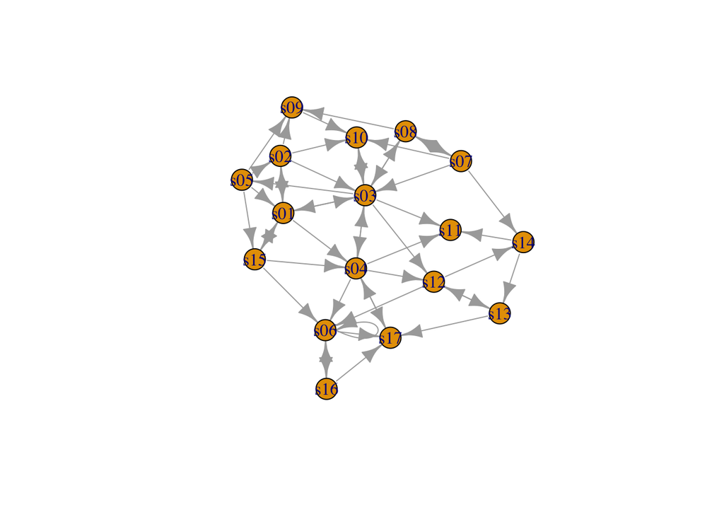

```r
plot(net)
```

This plot is not at all pretty.

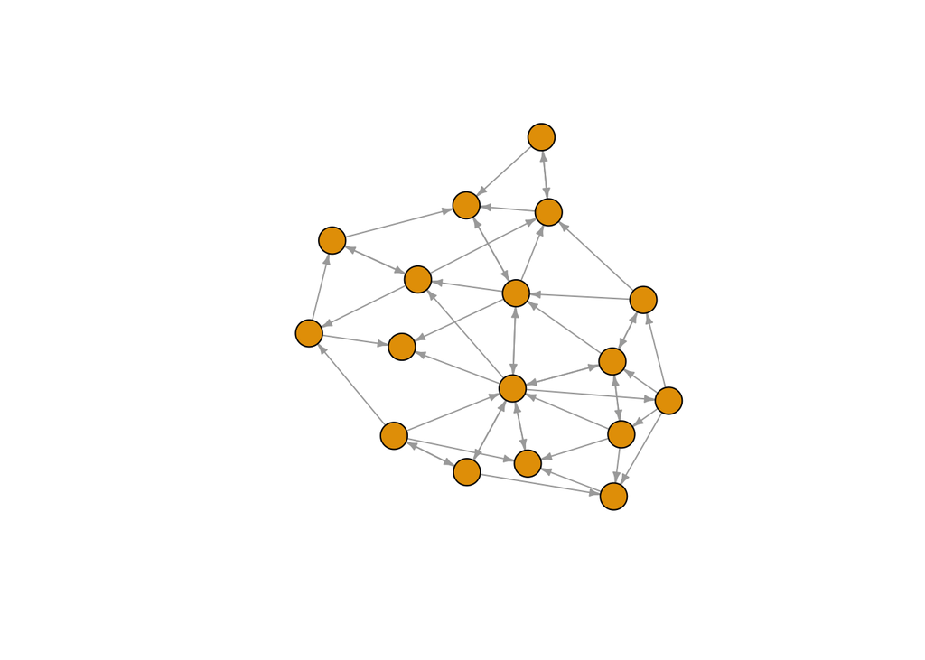

```r
net <- simplify(net, remove.multiple = F, remove.loops = T)
plot(net, edge.arrow.size=.4,vertex.label=NA)
```

Load the colors we shall use for the network building.

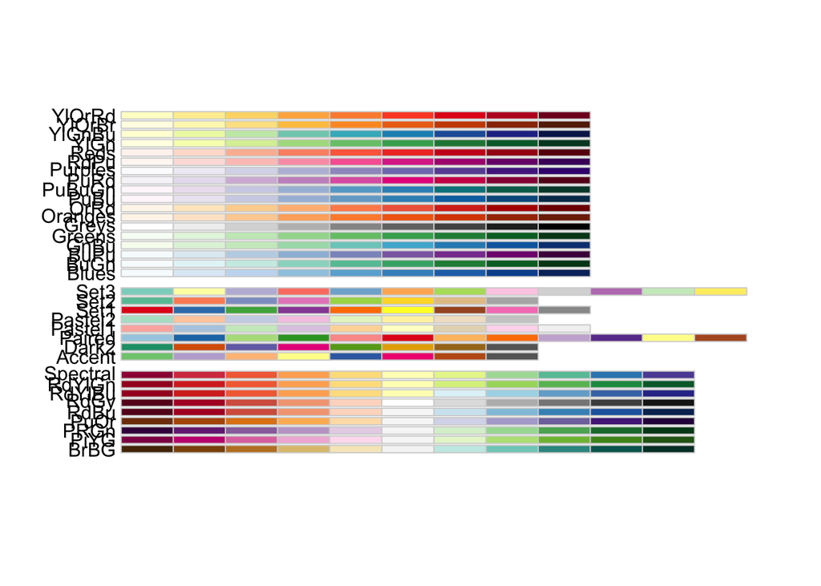

```r
display.brewer.all()
```

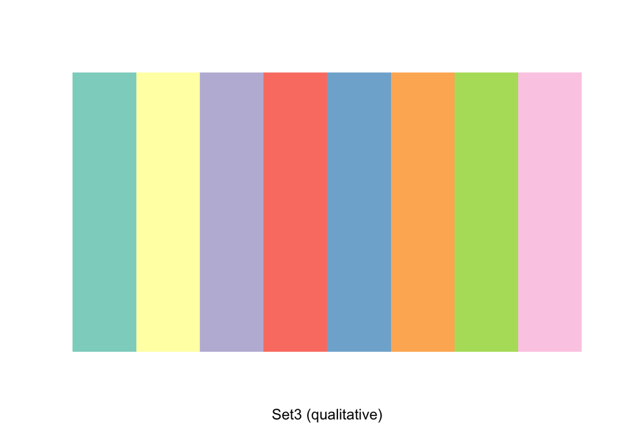

```r
display.brewer.pal(8, "Set3")
```

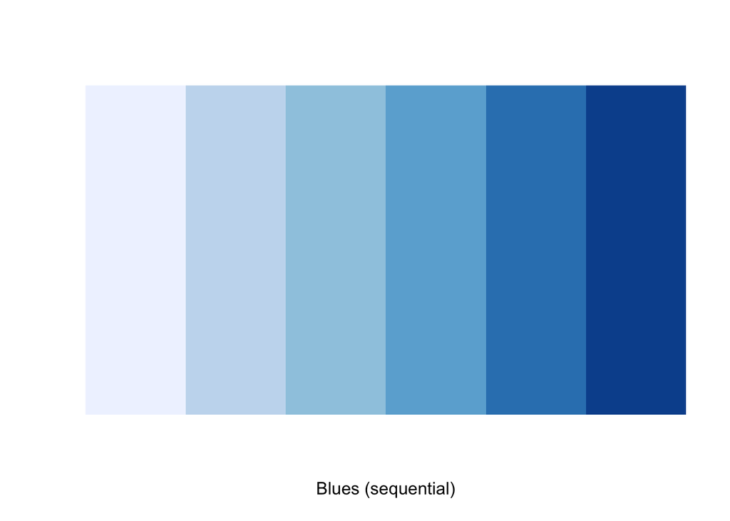

```r
display.brewer.pal(6, "Blues")
```

Lets look at the different types of fonts.

```r
# Import system fonts - may take a while, so DO NOT run this during the workshop.
#font_import()
fonts() # See what font families are available to you now.
```

```
##  [1] ".Keyboard"             "Andale Mono"
##  [3] "Apple Braille"         "AppleMyungjo"
##  [5] "Arial Black"           "Arial"
##  [7] "Arial Narrow"          "Arial Rounded MT Bold"
##  [9] "Arial Unicode MS"      "Bodoni Ornaments"
## [11] "Bodoni 72 Smallcaps"   ""
## [13] "Brush Script MT"       "Comic Sans MS"
## [15] "Courier New"           "DIN Alternate"
## [17] "DIN Condensed"         "Georgia"
## [19] "Impact"                "Khmer Sangam MN"
## [21] "Lao Sangam MN"         "Luminari"
## [23] "Microsoft Sans Serif"  "Myanmar Sangam MN"
## [25] "Tahoma"                "Times New Roman"
## [27] "Trattatello"           "Trebuchet MS"
## [29] "Verdana"               "Webdings"
## [31] "Wingdings"             "Wingdings 2"
## [33] "Wingdings 3"
```

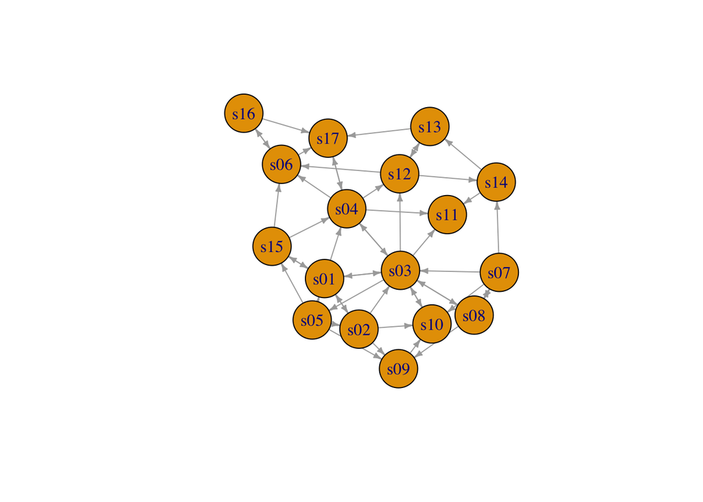

```r
plot(net, vertex.size=30, edge.arrow.size=.4)
```

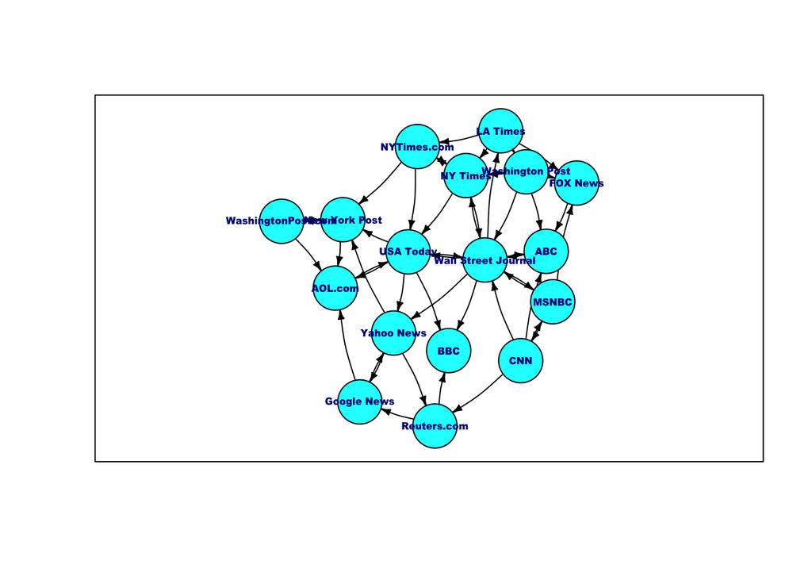

```r
plot(net, vertex.size=30, edge.arrow.size=.4,
     vertex.label.family="Arial Black",
     vertex.color="cyan",
     vertex.size=16,
     vertex.label.font=2,
     vertex.label.cex   =0.5,
     edge.color="black",
     frame=TRUE,
     edge.curved=0.1,
     vertex.label=V(net)$media)
```

We add more attributes to the network visualization.

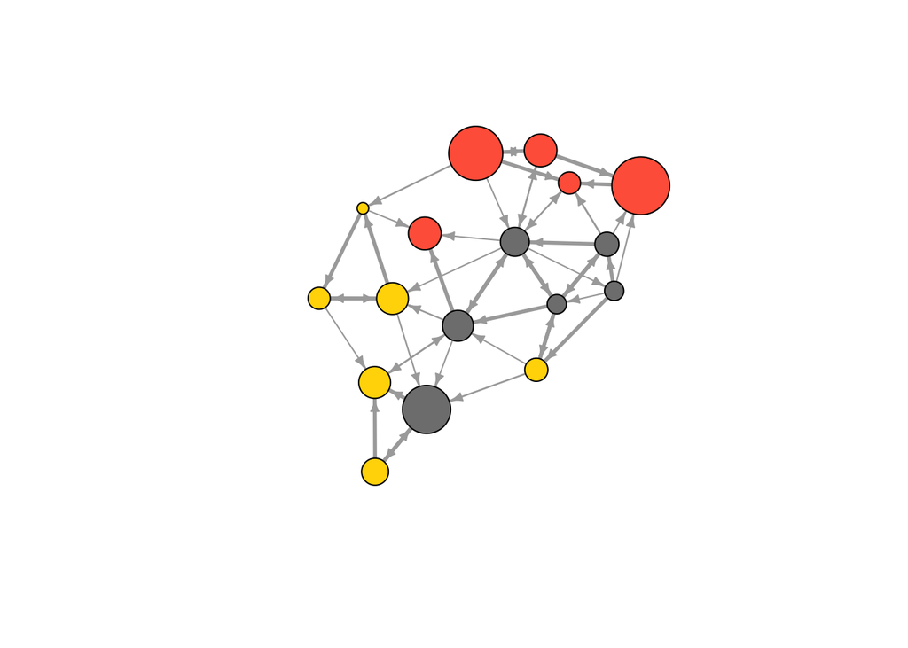

```r
# Generate colors base on media type:
colrs <- c("gray50", "tomato", "gold")
V(net)$color <- colrs[V(net)$media.type]

# Compute node degrees (#links) and use that to set node size:
deg <- igraph::degree(net, mode="all")
V(net)$size <- deg*3
# We could also use the audience size value:
V(net)$size <- V(net)$audience.size*0.6

# The labels are currently node IDs.
# Setting them to NA will render no labels:
V(net)$label <- NA

# Set edge width based on weight:
E(net)$width <- E(net)$weight/6

#change arrow size and edge color:
E(net)$arrow.size <- .5
E(net)$edge.color <- "gray80"
E(net)$width <- 1+E(net)$weight/12
plot(net)
```

We label the nodes by their type labels.

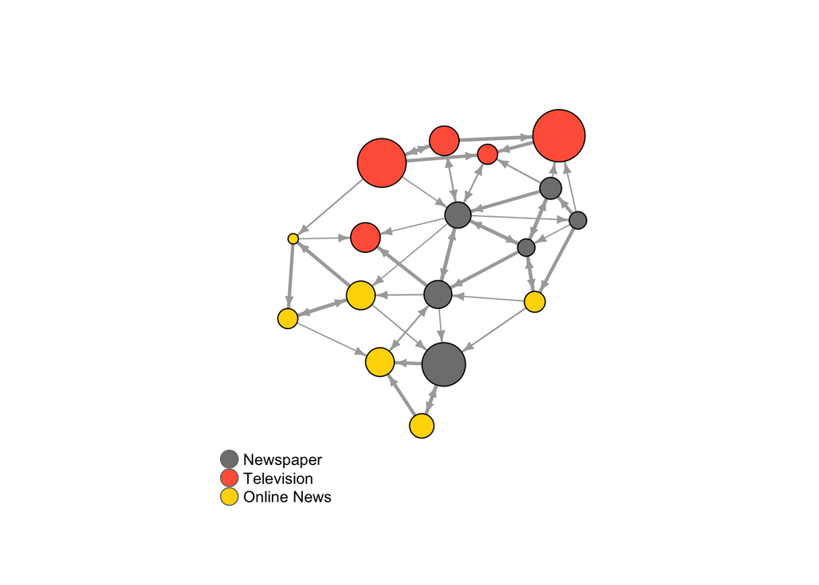

```r
plot(net)
legend(x=-1.5, y=-1.1, c("Newspaper","Television", "Online News"), pch=21, col="#777777", pt.bg=colrs, pt.cex=2, cex=.8,
bty="n", ncol=1)
```

In case, we do not want the node balls to show.

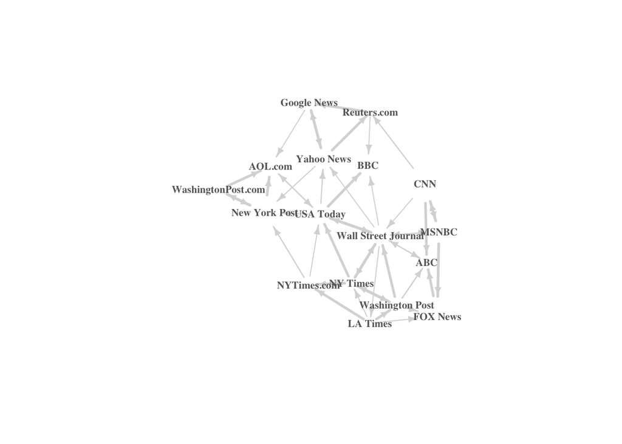

```r
plot(net, vertex.shape="none", vertex.label=V(net)$media,
     vertex.label.font=2, vertex.label.color="gray40",
     vertex.label.cex=.7, edge.color="gray85")
```

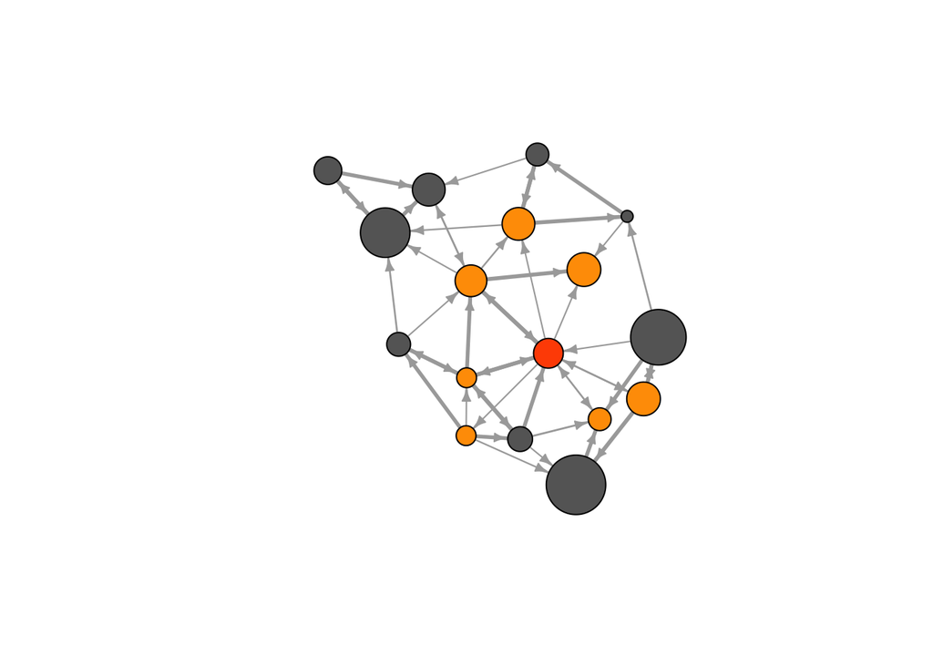

```r
col <- rep("grey40", vcount(net))
col[V(net)$media=="Wall Street Journal"] <- "#ff5100"
neigh.nodes <- neighbors(net, V(net)[media=="Wall Street Journal"], mode="out")
col[neigh.nodes] <- "#ff9d00"
plot(net, vertex.color=col)
```

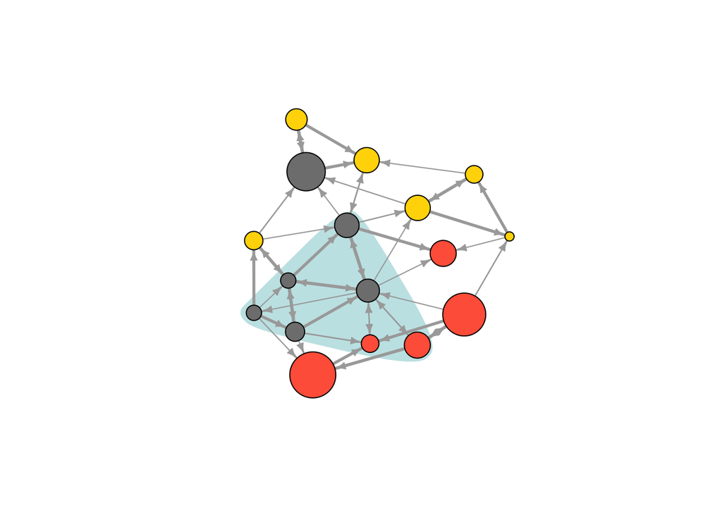

```r
plot(net, mark.groups=c(1,4,5,8), mark.col="#C5E5E7", mark.border=NA)
```

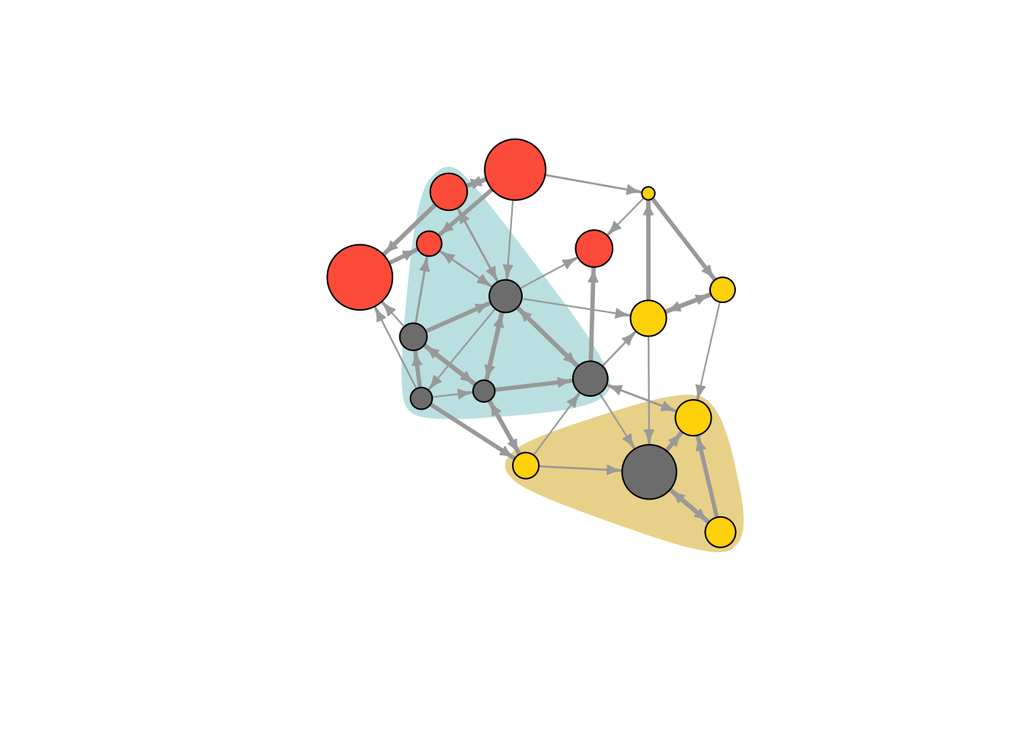

```r
plot(net, mark.groups=list(c(1,4,5,8), c(15:17)),
          mark.col=c("#C5E5E7","#ECD89A"), mark.border=NA)
```

We can use the heatmap representation of the network.

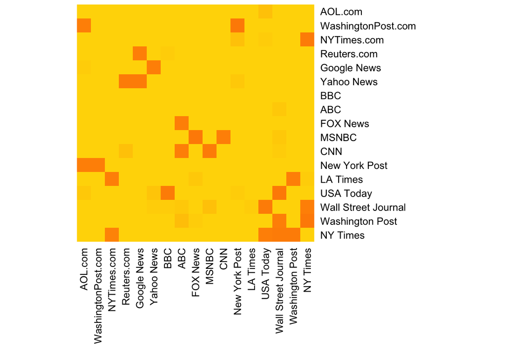

```r
netm <- get.adjacency(net, attr="weight", sparse=F)
colnames(netm) <- V(net)$media
rownames(netm) <- V(net)$media

palf <- colorRampPalette(c("gold", "dark orange"))
heatmap(netm[,17:1], Rowv = NA, Colv = NA, col = palf(100),
        scale="none", margins=c(10,10) )
```

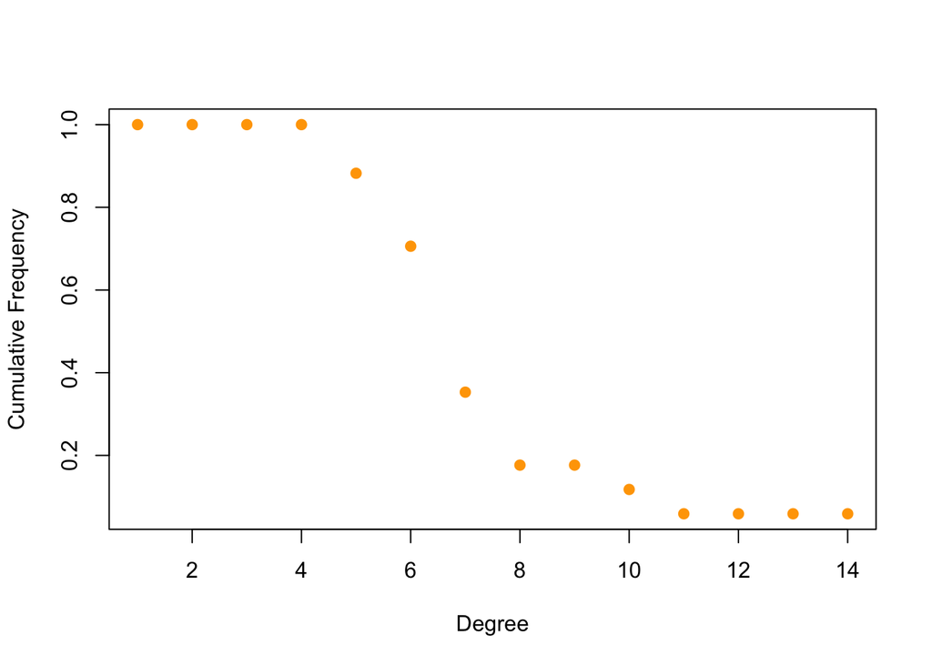

```r
dd <- degree.distribution(net, cumulative=T)
plot(dd, pch=19, cex=1, col="orange", xlab="Degree", ylab="Cumulative Frequency")
```

```r
net2 <- graph.incidence(links2)
table(E(net2)$type)
```

```
## < table of extent 0 >
```

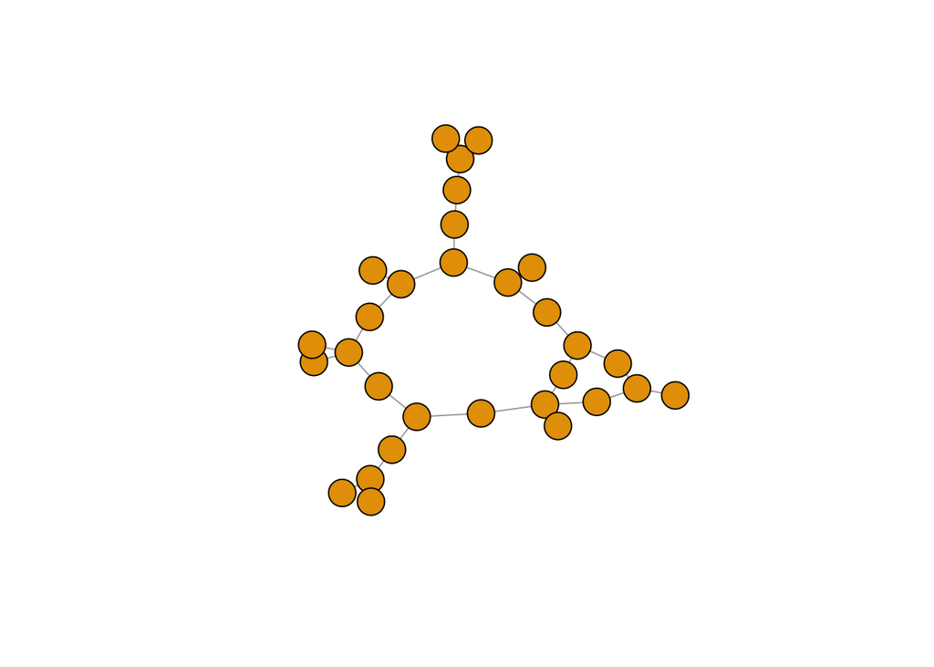

```r
plot(net2, vertex.label=NA)
```

We now use the network package to determine the network.

```r
library(network)
net3 <- network(links,  vertex.attr=nodes, matrix.type="edgelist",
                loops=F, multiple=F, ignore.eval = F)

net3[,]
```

```
##     s01 s02 s03 s04 s05 s06 s07 s08 s09 s10 s11 s12 s13 s14 s15 s16 s17
## s01   0   1   1   1   0   0   0   0   0   0   0   0   0   0   1   0   0
## s02   1   0   1   0   0   0   0   0   1   1   0   0   0   0   0   0   0
## s03   1   0   0   1   1   0   0   1   0   1   1   1   0   0   0   0   0
## s04   0   0   1   0   0   1   0   0   0   0   1   1   0   0   0   0   1
## s05   1   1   0   0   0   0   0   0   1   0   0   0   0   0   1   0   0
## s06   0   0   0   0   0   1   0   0   0   0   0   0   0   0   0   1   1
## s07   0   0   1   0   0   0   0   1   0   1   0   0   0   1   0   0   0
## s08   0   0   1   0   0   0   1   0   1   0   0   0   0   0   0   0   0
## s09   0   0   0   0   0   0   0   0   0   1   0   0   0   0   0   0   0
## s10   0   0   1   0   0   0   0   0   0   0   0   0   0   0   0   0   0
## s11   0   0   0   0   0   0   0   0   0   0   0   0   0   0   0   0   0
## s12   0   0   0   0   0   1   0   0   0   0   0   0   1   1   0   0   0
## s13   0   0   0   0   0   0   0   0   0   0   0   1   0   0   0   0   1
## s14   0   0   0   0   0   0   0   0   0   0   1   0   1   0   0   0   0
## s15   1   0   0   1   0   1   0   0   0   0   0   0   0   0   0   0   0
## s16   0   0   0   0   0   1   0   0   0   0   0   0   0   0   0   0   1
## s17   0   0   0   1   0   0   0   0   0   0   0   0   0   0   0   0   0
```

```r
net3 %n% "net.name" <- "Media Network" #  network attribute
net3 %v% "media"    # Node attribute
```

```
##  [1] "NY Times"            "Washington Post"     "Wall Street Journal"
##  [4] "USA Today"           "LA Times"            "New York Post"
##  [7] "CNN"                 "MSNBC"               "FOX News"
## [10] "ABC"                 "BBC"                 "Yahoo News"
## [13] "Google News"         "Reuters.com"         "NYTimes.com"
## [16] "WashingtonPost.com"  "AOL.com"
```

```r
net3 %e% "type"     # Node attribute
```

```
##  [1] "hyperlink" "hyperlink" "hyperlink" "mention"   "hyperlink"
##  [6] "hyperlink" "hyperlink" "hyperlink" "hyperlink" "hyperlink"
## [11] "hyperlink" "hyperlink" "mention"   "hyperlink" "hyperlink"
## [16] "hyperlink" "mention"   "mention"   "hyperlink" "mention"
## [21] "mention"   "hyperlink" "hyperlink" "mention"   "hyperlink"
## [26] "hyperlink" "mention"   "mention"   "mention"   "hyperlink"
## [31] "mention"   "hyperlink" "mention"   "mention"   "mention"
## [36] "hyperlink" "mention"   "hyperlink" "mention"   "hyperlink"
## [41] "mention"   "mention"   "mention"   "hyperlink" "hyperlink"
## [46] "hyperlink" "hyperlink" "mention"   "hyperlink"
```

```r
net3 %v% "col" <- c("gray70", "tomato", "gold")[net3 %v% "media.type"]
```